# Stablecoins â€” compare USDC, USDT and DAI transaction sizes and volumes

We want to compare three major Ethereum stablecoins: - USDC (smart contract address: 0xa0b86991c6218b36c1d19d4a2e9eb0ce3606eb48) - USDT (smart contract address: 0xdac17f958d2ee523a2206206994597c13d831ec7) - DAI (smart contract address: 0x6b175474e89094c44da98b954eedeac495271d0f)

Our workflow is:

```
Ethereum
   â†“
Etherscan
   â†“
ERC-20 transfer events
   â†“
R / tidyverse
   â†“
transfer sizes + transfer volumes
```

We use Etherscan to retrieve the already indexed ERC-20 transfer events. Etherscanâ€™s `tokentx` endpoint can be filtered directly by token contract, so we do not need to download unrelated ERC-20 transfers first.

We use the term transfer rather than transaction throughout the lab: one Ethereum transaction can generate several ERC-20 transfer events.

```r
library(tidyverse)
library(httr2)

api_key <- Sys.getenv("ETHERSCAN_API_KEY")

stablecoins <- tibble(
  token = c("USDC", "USDT", "DAI"),
  contract = c(
    "0xa0b86991c6218b36c1d19d4a2e9eb0ce3606eb48",
    "0xdac17f958d2ee523a2206206994597c13d831ec7",
    "0x6b175474e89094c44da98b954eedeac495271d0f"
  ),
  decimals = c(6, 6, 18)
)

etherscan <- function(...) {
  request("https://api.etherscan.io/v2/api") |>
    req_url_query(chainid = 1, apikey = api_key, ...) |>
    req_perform() |>
    resp_body_json(simplifyVector = TRUE)
}

end_block <- strtoi(substr(etherscan(module = "proxy", action = "eth_blockNumber")$result, 3, 20), base = 16L)
start_block <- end_block - 50

get_transfers <- function(contract, token) {
  page <- 1
  pages <- list()
  repeat {
    result <- etherscan(
      module = "account", action = "tokentx", contractaddress = contract,
      startblock = start_block, endblock = end_block,
      page = page, offset = 1000, sort = "asc"
    )$result
    if (is.character(result)) break
    pages[[page]] <- as_tibble(result)
    if (nrow(result) < 1000) break
    page <- page + 1
  }
  bind_rows(pages) |> mutate(token = token)
}

transfers <- map2_dfr(stablecoins$contract, stablecoins$token, get_transfers) |>
  left_join(stablecoins, join_by(token)) |>
  transmute(
    token,
    block = as.numeric(blockNumber),
    hash,
    amount = as.numeric(value) / 10^decimals
  )
```

We will investigate two questions: #1. How do their transfer sizes differ?

```r
transfers |>
  group_by(token) |>
  summarise(
    n_transfers = n(),
    first_block = min(block),
    last_block = max(block),
    mean = mean(amount),
    median = median(amount),
    max = max(amount)
  )
```

```
## # A tibble: 3 × 7
##   token n_transfers first_block last_block    mean median       max
##   <chr>       <int>       <dbl>      <dbl>   <dbl>  <dbl>     <dbl>
## 1 DAI           170    26336590   26336640  16003.   779.    200000
## 2 USDC         5003    26336590   26336640 141963.   143. 100200000
## 3 USDT         2000    26336590   26336609   9579.   100    5000000
```

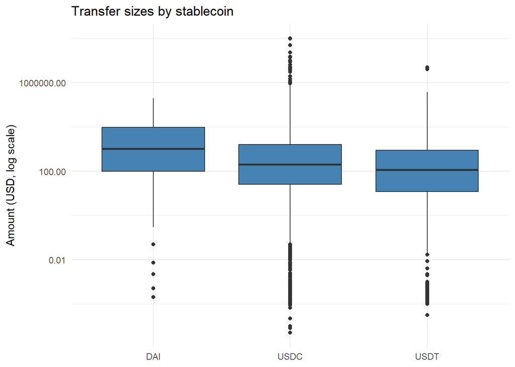

```r
transfers |>
  filter(amount > 0) |>
  ggplot(aes(x = token, y = amount)) +
  geom_boxplot(fill = "steelblue") +
  scale_y_log10(labels = function(x) format(x, scientific = FALSE, trim = TRUE)) +
  labs(title = "Transfer sizes by stablecoin", x = NULL, y = "Amount (USD, log scale)") +
  theme_minimal()
```

I trasferimenti mostrano una forte asimmetria con una coda lunga, dove la grande maggioranza delle transazioni ha importi ridotti ma pochissimi trasferimenti enormi

#2. How much transfer volume does each stablecoin generate?

```r
volume <- transfers |>
  group_by(token) |>
  summarise(n_transfers = n(), total_volume = sum(amount))

volume
```

```
## # A tibble: 3 × 3
##   token n_transfers total_volume
##   <chr>       <int>        <dbl>
## 1 DAI           170     2720488.
## 2 USDC         5003   710243065.
## 3 USDT         2000    19158540.
```

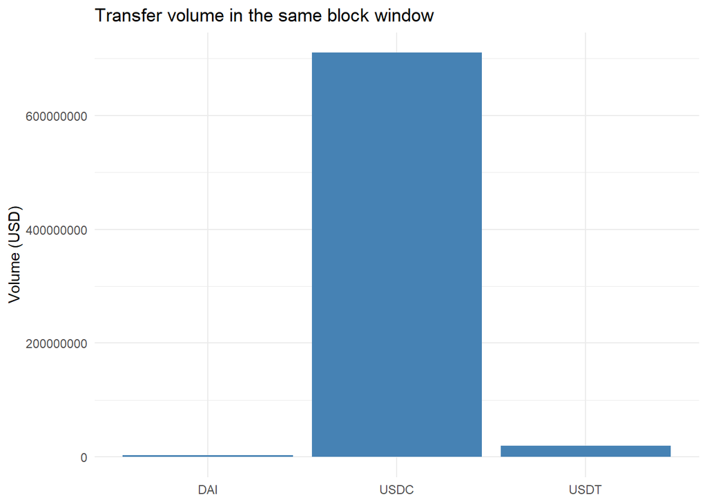

```r
ggplot(volume, aes(x = token, y = total_volume)) +
  geom_col(fill = "steelblue") +
  scale_y_continuous(labels = function(x) format(x, scientific = FALSE, trim = TRUE)) +
  labs(title = "Transfer volume in the same block window", x = NULL, y = "Volume (USD)") +
  theme_minimal()
```